# Agricultural Trends

Hadrien@rstudio.com

3/27/2019

# Overview

This analysis aims to better understand agricultural production trends in order to better guide decisions related to the manufacture of farming equipment to ensure future food security in different geographies.

**Data:** Data for this analysis was obtained from the [Food and Agricultural Organization of the United Nations](http://www.fao.org/faostat/en/#data/QC) website on April 1st, 2019. Data was downloaded as the bulk download “All Data”.

**Using this report**

To view this report, go to the report URL on RStudio Connect. On the left hand side of the report, select your desired input paramaters and click run. A report can be generated for any country & crop combination. This report was designed for the following users:

- Marketing managers: explore production trends to plan which markets to invest in and create campaigns for.
- Product managers: identify which product lines to invest in to help farmers overcome challenges such as droughts and desertification and meet the demand of an ever increasing population.

**Contributing**

To contribute to this project, fork this report’s repository on [github](https://github.com/hdykiel/paramaterized-report-agriculture/commits/master) and create a new branch using the format “your-name-feature-name” and submit a pull request.

### Worldwide production of Wheat

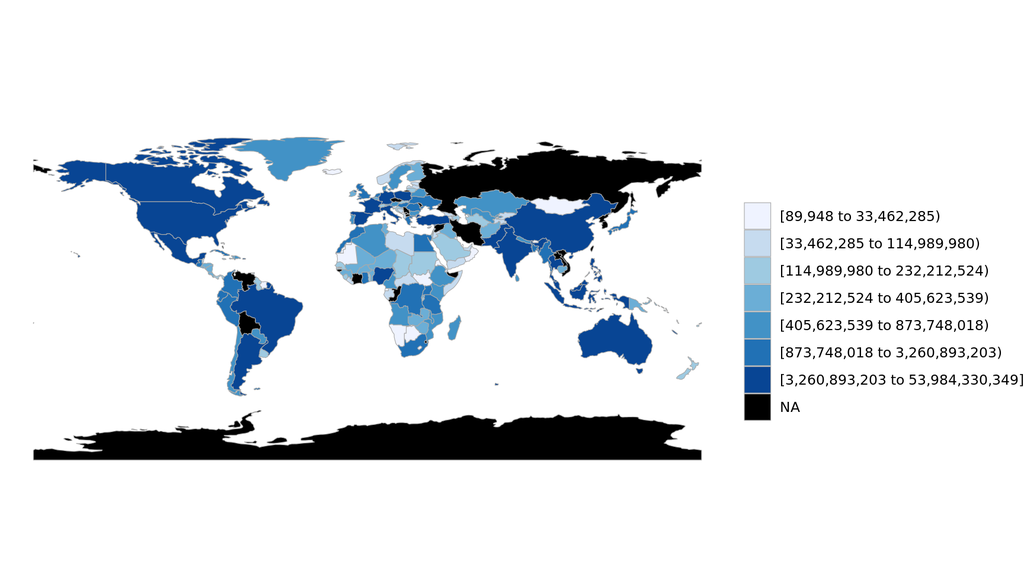

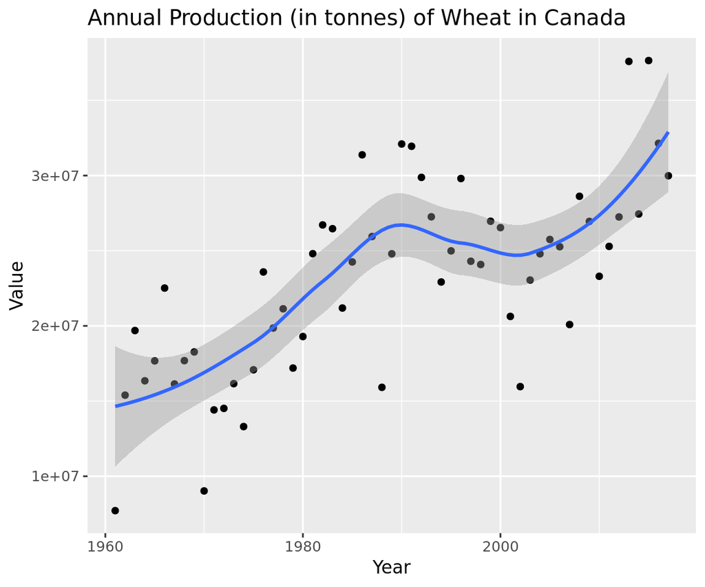